# Target Product Profile

Suzanne Dufault

2022-06-09

# Target Product Profile Walk-Through

Using notation from Pulkstenis et al. The target product profile (TPP) requires the specification of four primary quantities of interest:

- $\theta_{LRV}$: **lower reference value**, the minimal level of acceptable efficacy
  - $\tau_{LRV}$: **false GO rate**, the maximum allowable risk that you advance a regimen that does not reach the minimal level of acceptable efficacy
- $\theta_{TV}$: **target value**, the level of efficacy corresponding to solid competitiveness
  - $\tau_{TV}$: **false NO-GO rate**, the maximum allowable risk that you stop a regimen that does have solid competitiveness

## Single Example

In a single study, we can visualize this in a handful of ways. Below is an example from the simulated data comparing 4 novel regimens against a control with 30 participants assigned per regimen. **Panel A** shows the posterior distributions for the estimated % increase in log10(TTP) slope of each regimen relative to the control regimen. **Panel B** shows the Bayesian credible intervals for each regimen. These are used for decision-making.

In this example:

- $\theta_{LRV} =$ 0%
- $\theta_{TV}=$ 20%
- $\tau_{LRV} = \tau_{TV} = 2.5$%

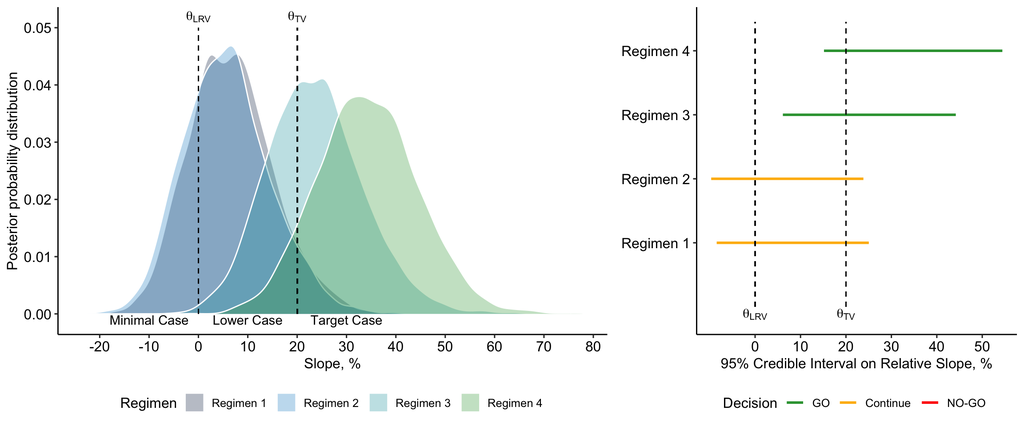

Recreation of Figure 1 from Pulkstenis et al.

## Across Simulations

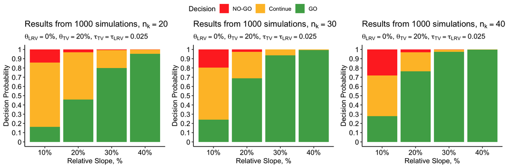

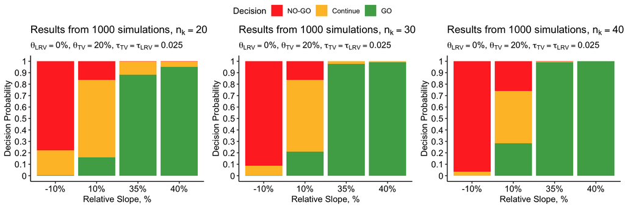

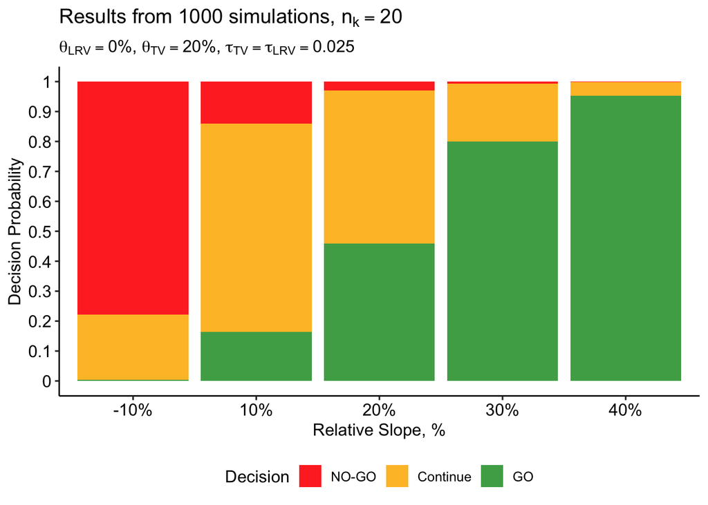

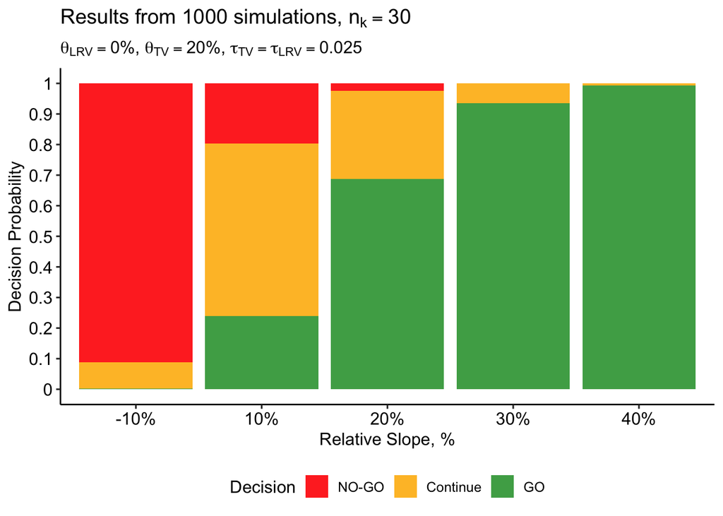

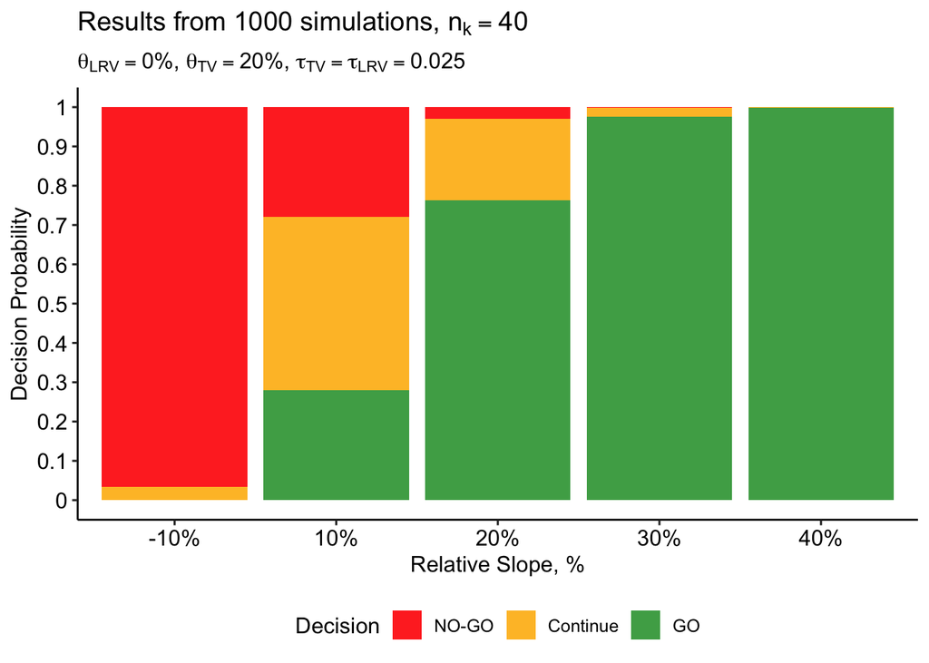

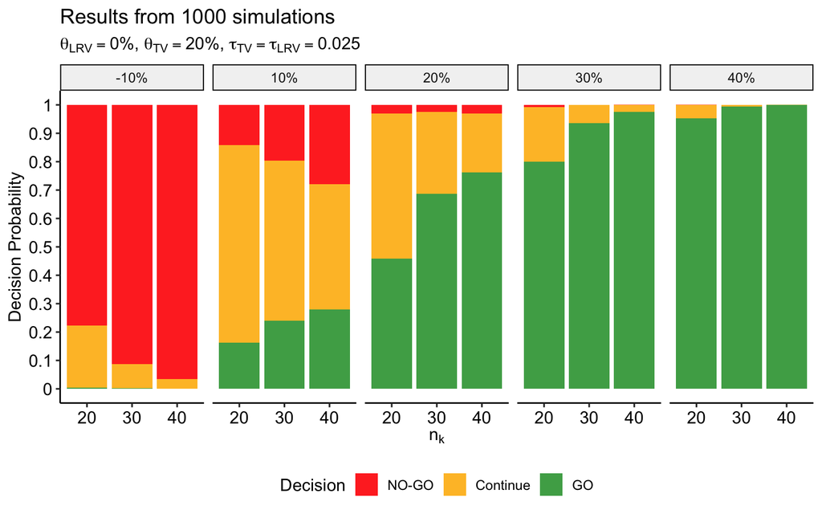

### Varying LRV

Fixing the TV at 20%.

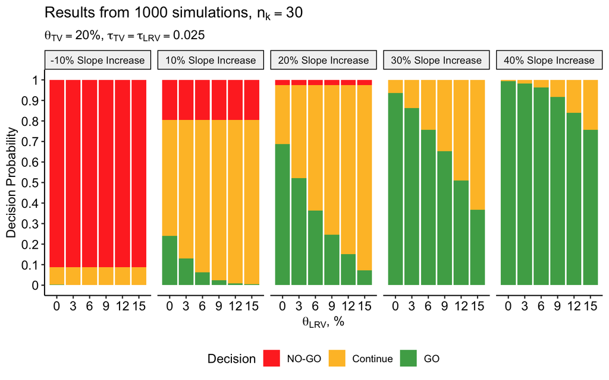

### Varying TV

Fixing the LRV at 0%.

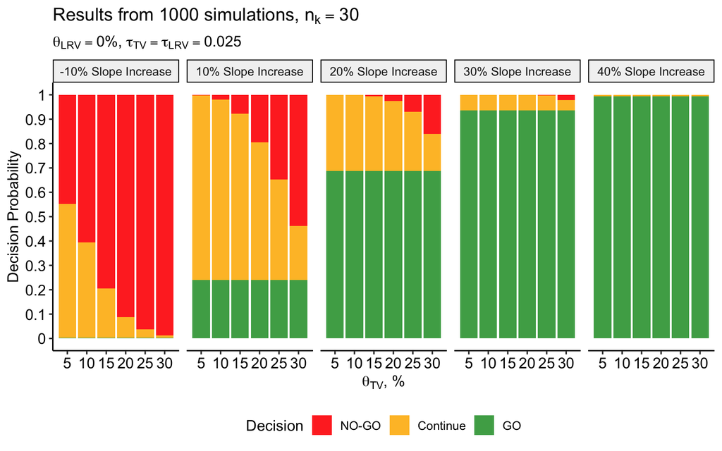

### Varying false NO-GO risk

Fixing $\theta_{LRV} = 0$%, $\theta_{TV} = 20$%, and $\tau_{LRV} = 2.5$%.

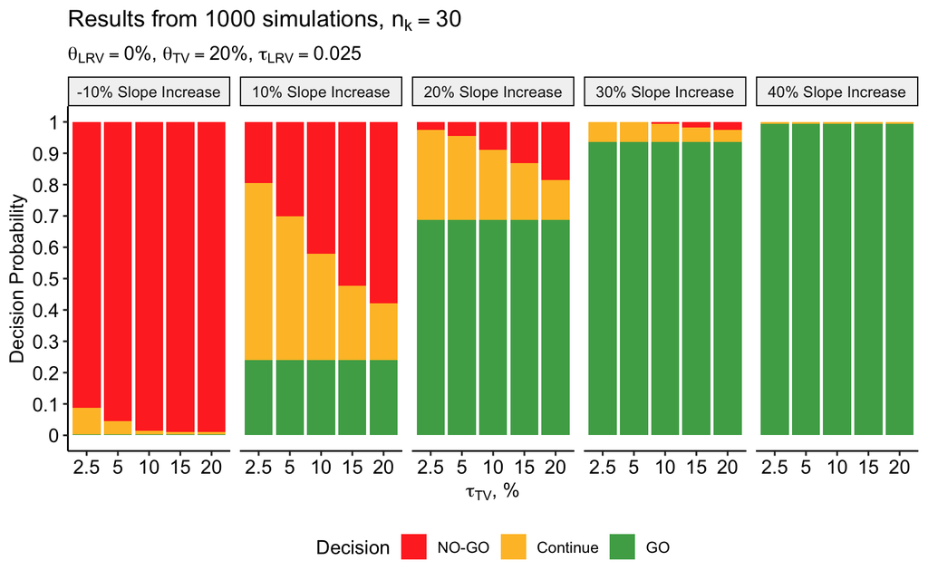

### Varying false GO risk

Fixing $\theta_{LRV} = 0$%, $\theta_{TV} = 20$%, and $\tau_{TV} = 2.5$%.

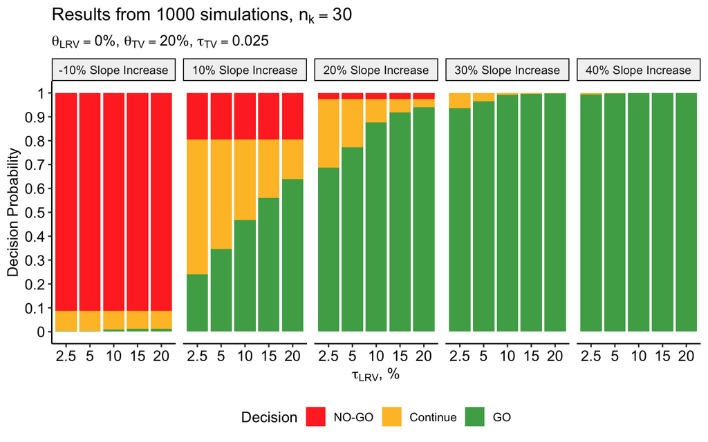